# Hospital Appointment Management and Patient Attendance Analysis Using R

Attendance patterns and probability prediction using Random Forest and XGBoost

Harshit Srinivasa Prasad

15 October 2026

# 1 Abstract

Missed hospital appointments create uncertainty in scheduling and can leave capacity unused. This study analyses historical appointment records and estimates attendance probabilities using Random Forest and XGBoost. The working file contains 53,978 appointments before cleaning and 53,976 afterward. Preparation includes checking records, correcting target labels, converting dates and calculating waiting days. Patients remain separate across training, validation and testing partitions. Validation F1 selects follow-up thresholds, while test evaluation includes precision, recall, F1 and Brier score. Random Forest obtains test F1 0.4450 and XGBoost obtains 0.4468. The final demonstration reports attending and missing probabilities for a fictional appointment. The results support reminder prioritisation as a research prototype. They do not establish that reminders improve attendance or that the model transfers to other hospitals. Incomplete source coverage and the absence of several personal and operational factors limit the findings.

# 2 Introduction

## 2.1 Background

Hospital staff must plan appointments despite uncertainty about patient attendance. Historical records can identify patterns and support estimates of missed-appointment risk.

## 2.2 Problem statement

How can historical patient and appointment information help identify appointments at higher risk of being missed, while reporting the probability of attendance?

## 2.3 Objectives

1. Prepare appointment records for analysis.
2. Compare attendance across age groups, gender, waiting periods and SMS status.
3. Train Random Forest and XGBoost probability models.
4. Select follow-up thresholds using validation data and evaluate test performance.
5. Demonstrate attending and missing probabilities for a new fictional patient.

## 2.4 Scope

The implementation analyses attendance and predicts outcomes. It does not book, cancel or reschedule appointments, and it does not send SMS messages. The SMS indicator must already be available at the time a prediction is made.

# 3 Data

## 3.1 Source and variables

The working file is `KaggleV2-May-2016.csv`, associated with the Medical Appointment No Shows dataset. Each row represents an appointment; patients can appear more than once. Counts below describe the imported working file, which may be a subset of the original dataset.

| Variable | Description |
| --- | --- |
| `PatientId`, `AppointmentID` | Patient and appointment identifiers |
| `Gender`, `Age` | Recorded demographic details |
| `ScheduledDay`, `AppointmentDay` | Booking and appointment dates |
| `Neighbourhood` | Recorded neighbourhood |
| `Scholarship` | Welfare programme indicator |
| `Hipertension`, `Diabetes`, `Alcoholism` | Recorded health indicators |
| `Handcap` | Recorded disability category |
| `SMS_received` | Recorded SMS reminder indicator; does not prove reading |
| `verification` | Target renamed from No-show, recoded as Attended or Missed |
| `WaitingDays` | Appointment date minus booking date in calendar days |

The original **No-show = Yes** means **Missed**, while **No** means **Attended**.

## 3.2 Dataset size at each stage

Appointments at each stage

| Stage | Appointments |
| --- | --- |
| Imported file | 53978 |
| After cleaning | 53976 |
| Model training | 34719 |
| Validation | 8597 |
| Testing | 10660 |

# 4 Methodology

## 4.1 Overall workflow

1. Import and inspect the CSV.
2. Clean records and calculate waiting days.
3. Separate patients into training, validation and testing partitions.
4. Fit Random Forest and XGBoost on model-training records.
5. Select thresholds on validation records.
6. Evaluate fixed models and thresholds on testing records.
7. Interpret attendance patterns and demonstrate a new appointment prediction.
8. Save models, results and report data.

## 4.2 Data cleaning

The notebook checks missing values, duplicate rows and data types. It removes negative ages, converts date fields and excludes invalid waiting periods. Age zero remains valid for infants. Repeated patients remain in the dataset because separate appointments are legitimate observations.

Missing values after cleaning

| Column | Missing |
| --- | --- |
| PatientId | 0 |
| AppointmentID | 0 |
| Gender | 0 |
| ScheduledDay | 0 |
| AppointmentDay | 0 |
| Age | 0 |
| Neighbourhood | 0 |
| Scholarship | 0 |
| Hipertension | 0 |
| Diabetes | 0 |
| Alcoholism | 0 |
| Handcap | 0 |
| SMS_received | 0 |
| verification | 0 |
| WaitingDays | 0 |

## 4.3 Feature engineering

Waiting days uses calendar dates rather than timestamp subtraction. The target uses explicit outcome labels. Gender becomes indicator columns for XGBoost. Identifiers and the attendance target are excluded from the predictor matrix.

Selected predictors

| Predictor |
| --- |
| Age |
| Gender |
| Scholarship |
| Hipertension |
| Diabetes |
| Alcoholism |
| Handcap |
| SMS_received |
| WaitingDays |

## 4.4 Training validation and testing

Approximately 80% of patients enter the outer training partition. Of those, approximately 20% enter validation. The remaining patients form the test set. Appointment proportions differ because patients have different record counts.

Patient overlap checks

| Pair | Shared_patients |
| --- | --- |
| Training_Validation | 0 |
| Training_Testing | 0 |
| Validation_Testing | 0 |

## 4.5 Models and evaluation

| Model | Configuration | Evaluation |
| --- | --- | --- |
| Random Forest | 300 trees, mtry 3, minimum node size 20, probability forest | Precision, recall, F1, accuracy, Brier score |
| XGBoost | Binary logistic, eta 0.05, depth 4, child weight 10, row and column sampling 0.8 | Same test metrics; validation log loss for early stopping |

Both models use seed 33. XGBoost allows up to 500 rounds and stops after 30 rounds without validation improvement. Thresholds from 0.01 to 0.99 maximise validation F1. The test set does not determine thresholds. Random Forest uses the method implemented in `ranger` (Wright and Ziegler, 2017); XGBoost follows the boosting system described by Chen and Guestrin (2016).

# 5 Exploratory data analysis

## 5.1 Outcome distribution

Attendance distribution

| Outcome | Count | Percent |
| --- | --- | --- |
| Attended | 42599 | 78.92 |
| Missed | 11377 | 21.08 |

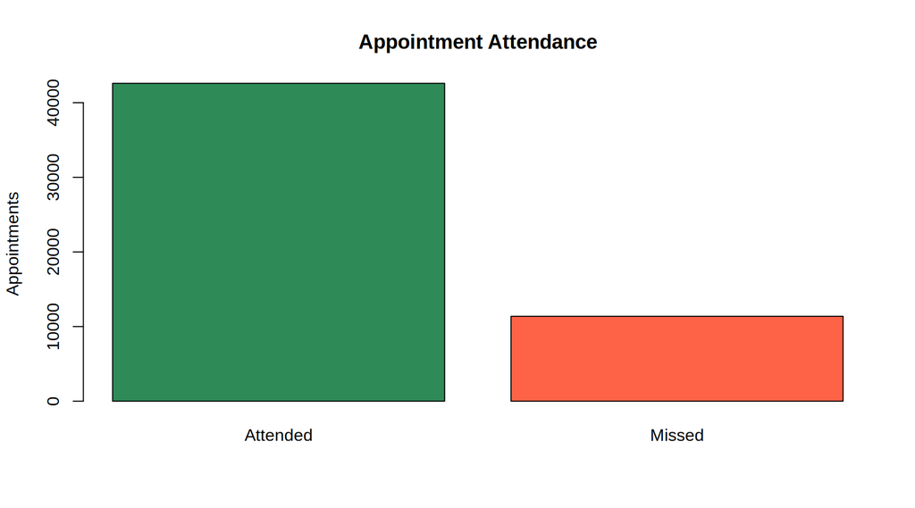

The missed rate is **21.08%**. A model can obtain high accuracy by predicting the majority class, so missed-class recall matters.

## 5.2 Patient and appointment groups

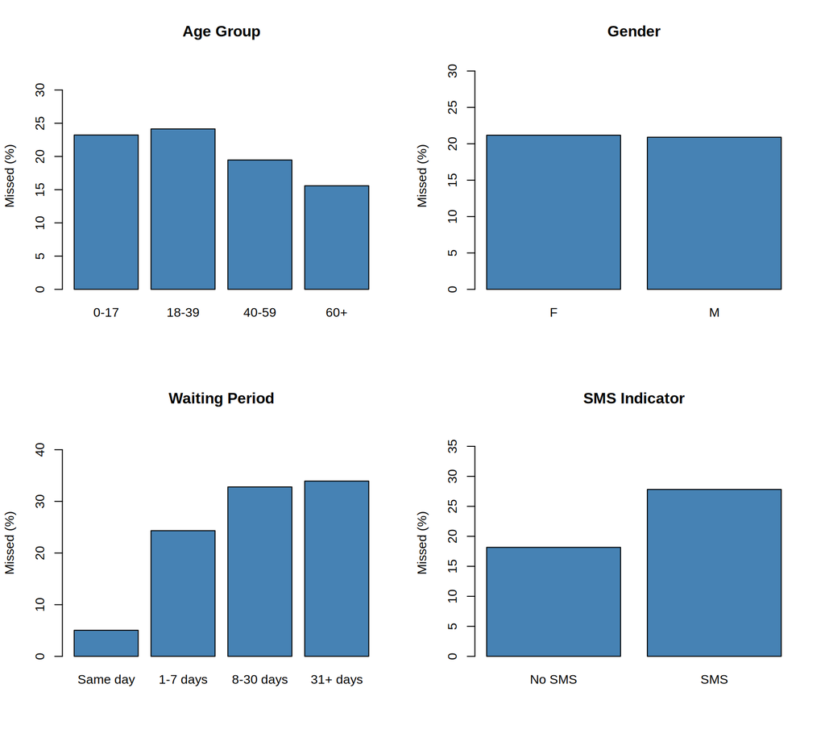

Percentages compare groups of unequal sizes. These are descriptive associations, not evidence that a characteristic causes missed appointments. SMS groups may differ in waiting periods and other factors.